# Project - Applied Statistics

## Project Statement - Statistical Learning

### Data - insurance.csv

#### *Import important libraries*

```python
#1. Import the necessary libraries.
import numpy as np # Basic linear algebra library.
import pandas as pd # To read data frame.
import seaborn as sns # For rich visualization.
import matplotlib.pyplot as plt # For additional graph features.
sns.set(color_codes=True) # Enable color feature of Seaborn.
import statsmodels.api as sm # For QQ plot
import scipy.stats as stats #For distribution values.
from sklearn.preprocessing import LabelEncoder # For Categorical data.
# Display the graph using semi colon in the same line.
%matplotlib inline
```

*IMPORTANCE: Necessary libraries imported to activate modules, its classes-functions-objects.*

#### *Read the data as a data frame*

```python
#2. Read & check the data as DataFrame.
ins_data = pd.read_csv("insurance.csv") # Read data as DataFrame.
print(ins_data.head()) # Summary of first 5 rows.
```

```
   age     sex     bmi  children smoker     region      charges
0   19  female  27.900         0    yes  southwest  16884.92400
1   18    male  33.770         1     no  southeast   1725.55230
2   28    male  33.000         3     no  southeast   4449.46200
3   33    male  22.705         0     no  northwest  21984.47061
4   32    male  28.880         0     no  northwest   3866.85520
```

*IMPORTANCE: Reading external data source by creating python object.*

#### *EDA-shape & type of Data*

```python
#3.1 EDA-shape attribute on data to get the shape of DataFrame.
rows,cols = ins_data.shape
print(ins_data.shape)
print(f"\nShape of data gives:\n\nNumber of rows/observations: {rows}\nNumber of columns/attributes: {cols}")
```

```
(1338, 7)

Shape of data gives:

Number of rows/observations: 1338
Number of columns/attributes: 7
```

```python
#3.2 EDA-dtypes attribute on data to get the type of data in DataFrame.
print(ins_data.dtypes)
```

```
age           int64
sex          object
bmi         float64
children      int64
smoker       object
region       object
charges     float64
dtype: object
```

```python
#Printing datatypes.
dat_typ = ins_data.dtypes
```

```python
print(f'''We have three datatypes in given dataset:\n
      First: Integer values\n{dat_typ[dat_typ=="int64"]}\n
      Second: Decimal values\n{dat_typ[dat_typ=="float64"]}\n
      Third: Strings\n{dat_typ[dat_typ=="object"]}''')
```

```
We have three datatypes in given dataset:

      First: Integer values
age         int64
children    int64
dtype: object

      Second: Decimal values
bmi        float64
charges    float64
dtype: object

      Third: Strings
sex       object
smoker    object
region    object
dtype: object
```

```
Children is categorical data
```

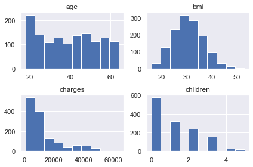

```python
#General check of numerical data distribution.
ins_data.hist();
plt.tight_layout()
print("Children is categorical data")
```

*IMPORTANCE:*

- Quick check of rows & cols.
- Quick check of type of data dealing with.
- Quick check of numerical data distribution

#### *EDA-Checking the presence of missing values*

```python
#4. EDA-Checking the presence of missing values using the combination of isnull & sum function.
print(ins_data.isnull().sum())
print("\nNo missing values found in data.")
```

```
age         0
sex         0
bmi         0
children    0
smoker      0
region      0
charges     0
dtype: int64

No missing values found in data.
```

```python
#Alternatively we can use .info() to get complete view of data set.
print("Non-Null Count shows there is no null value in data set\nComplete check of no. of rows & columns\nData types also given.\n")
null_val_chk = ins_data.info
null_val_chk()
```

```
Non-Null Count shows there is no null value in data set
Complete check of no. of rows & columns
Data types also given.

<class 'pandas.core.frame.DataFrame'>
RangeIndex: 1338 entries, 0 to 1337
Data columns (total 7 columns):
 #   Column    Non-Null Count  Dtype
---  ------    --------------  -----
 0   age       1338 non-null   int64
 1   sex       1338 non-null   object
 2   bmi       1338 non-null   float64
 3   children  1338 non-null   int64
 4   smoker    1338 non-null   object
 5   region    1338 non-null   object
 6   charges   1338 non-null   float64
dtypes: float64(2), int64(2), object(3)
memory usage: 57.6+ KB
```

*IMPORTANCE: Null value can be removed or filled as per requirement of analysis.*

#### EDA-5 point summary of numerical attributes. min 1st quartile 2nd quartile or median 3rd quartile max

```python
#5. EDA-5 point summary of numerical attributes using df.describe() function.
data1 = ins_data.describe()
print(data1.iloc[3:,:])
```

```
      age       bmi  children       charges
min  18.0  15.96000       0.0   1121.873900
25%  27.0  26.29625       0.0   4740.287150
50%  39.0  30.40000       1.0   9382.033000
75%  51.0  34.69375       2.0  16639.912515
max  64.0  53.13000       5.0  63770.428010
```

```python
#5.1 MIN values of numerical attributes.
print("MIN values are:\n",ins_data[["age","bmi","charges"]].min())
```

```
MIN values are:
 age          18.0000
bmi          15.9600
charges    1121.8739
dtype: float64
```

```python
#5.2 Q1=25% values of numerical attributes.
print("Quantile 25% are:\n",ins_data[["age","bmi","charges"]].quantile(0.25))
```

```
Quantile 25% are:
 age          27.00000
bmi          26.29625
charges    4740.28715
Name: 0.25, dtype: float64
```

```python
#5.3 Q2=50%(Median) values of numerical attributes.
print("Quantile 50% are:\n",ins_data[["age","bmi","charges"]].quantile(0.50))
```

```
Quantile 50% are:
 age          39.000
bmi          30.400
charges    9382.033
Name: 0.5, dtype: float64
```

```python
#5.4 Q3=75% values of numerical attributes.
print("Quantile 75% are:\n",ins_data[["age","bmi","charges"]].quantile(0.75))
```

```
Quantile 75% are:
 age           51.000000
bmi           34.693750
charges    16639.912515
Name: 0.75, dtype: float64
```

```python
#5.5 MAX values of numerical attributes.
print("MAX values are:\n",ins_data[["age","bmi","charges"]].max())
```

```
MAX values are:
 age           64.00000
bmi           53.13000
charges    63770.42801
dtype: float64
```

#### Box plot to visualize 5 point summary for "age", "bmi" & "charges" columns

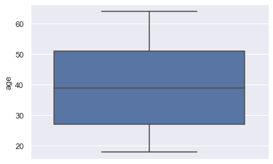

```python
sns.boxplot(data=ins_data,x="age",orient="v");
```

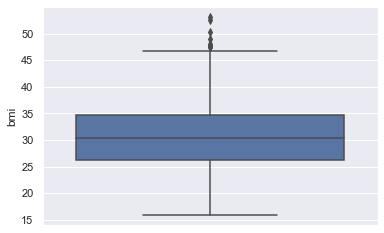

```python
sns.boxplot(data=ins_data,x="bmi",orient="v");
```

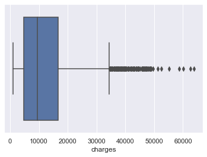

```python
sns.boxplot(data=ins_data,x="charges");
```

```python
#Calculate IQR.
quantile_1 = ins_data[["age","bmi","charges"]].quantile(0.25)
quantile_3 = ins_data[["age","bmi","charges"]].quantile(0.75)
IQR_val = quantile_3-quantile_1
print(IQR_val)
```

```
age           24.000000
bmi            8.397500
charges    11899.625365
dtype: float64
```

```python
#Calculate Range.
min_1 = ins_data[["age","bmi","charges"]].min()
max_1 = ins_data[["age","bmi","charges"]].max()
range_val = max_1-min_1
print(range_val)
```

```
age           46.00000
bmi           37.17000
charges    62648.55411
dtype: float64
```

*IMPORTANCE:*

- Gives descriptive analysis of data set.
- Gives most extreme values, lower quartiles, median & upper quartiles.
- Complete range can be calculated with (MAX-MIN)
- Inter Quartile Range can be calculated with (Q3-Q1), contains 50% of data.

All the statistics is good.  
Charges found high right skewed.

#### *EDA-Distribution of "bmi","age", & "charges" columns*

```
32.300    13
28.310     9
31.350     8
30.800     8
30.875     8
Name: bmi, dtype: int64
```

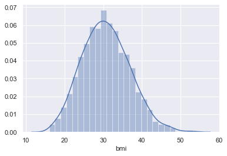

```python
#6.1 EDA-Distribution of "bmi"
sns.distplot(ins_data["bmi"]);
print(ins_data["bmi"].value_counts().head())
```

```
MIN: 15.96
MAX: 53.13
MEAN: 30.663396860986538
MEDIAN: 30.4
MODE: 32.3
Q1: 26.29625
Q3: 34.69375
```

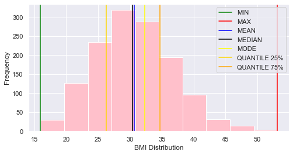

```python
#6.1.1 Main values of distribution of "bmi"
minim = ins_data["bmi"].min()
maxim = ins_data["bmi"].max()
mean_val = ins_data["bmi"].mean()
median_val = ins_data["bmi"].median()
mode_val= ins_data["bmi"].mode()
Q1_val = ins_data["bmi"].quantile(0.25)
Q3_val = ins_data["bmi"].quantile(0.75)
print(f"MIN: {minim}\nMAX: {maxim}\nMEAN: {mean_val}\nMEDIAN: {median_val}\nMODE: {mode_val[0]}\nQ1: {Q1_val}\nQ3: {Q3_val}")

plt.figure(figsize=(8,4))
plt.hist(ins_data["bmi"],color="pink")

plt.axvline(minim,color="green",label="MIN")
plt.axvline(maxim,color="red",label="MAX")
plt.axvline(mean_val,color="blue",label="MEAN")
plt.axvline(median_val,color="black",label="MEDIAN")
plt.axvline(mode_val[0],color="yellow",label="MODE")
plt.axvline(Q1_val,color="gold",label="QUANTILE 25%")
plt.axvline(Q3_val,color="orange",label="QUANTILE 75%")

plt.xlabel("BMI Distribution")
plt.ylabel("Frequency")
plt.legend()
plt.show()
```

```
BMI Data: NORMAL DISTRIBUTION
```

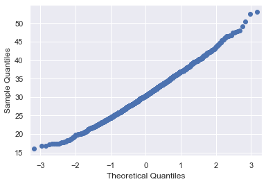

```python
#6.1.2 Type of distribution of "bmi"
sm.qqplot(ins_data["bmi"]);
print("\nBMI Data: NORMAL DISTRIBUTION")
```

```
18    69
19    68
51    29
45    29
46    29
Name: age, dtype: int64
```

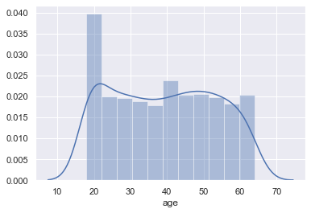

```python
#6.2 EDA-Distribution of "age"
sns.distplot(ins_data["age"]);
print(ins_data["age"].value_counts().head())
```

```
MIN: 18
MAX: 64
MEAN: 39.20702541106129
MEDIAN: 39.0
MODE: 18
Q1: 27.0
Q3: 51.0
```

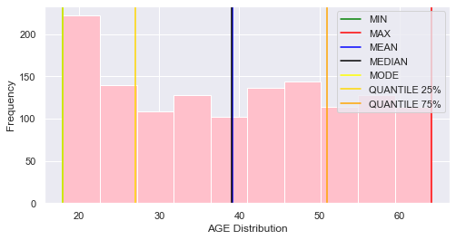

```python
#6.2.1 Main values of distribution of "age"
minim = ins_data["age"].min()
maxim = ins_data["age"].max()
mean_val = ins_data["age"].mean()
median_val = ins_data["age"].median()
mode_val= ins_data["age"].mode()
Q1_val = ins_data["age"].quantile(0.25)
Q3_val = ins_data["age"].quantile(0.75)
print(f"MIN: {minim}\nMAX: {maxim}\nMEAN: {mean_val}\nMEDIAN: {median_val}\nMODE: {mode_val[0]}\nQ1: {Q1_val}\nQ3: {Q3_val}")

plt.figure(figsize=(8,4))
plt.hist(ins_data["age"],color="pink")

plt.axvline(minim,color="green",label="MIN")
plt.axvline(maxim,color="red",label="MAX")
plt.axvline(mean_val,color="blue",label="MEAN")
plt.axvline(median_val,color="black",label="MEDIAN")
plt.axvline(mode_val[0],color="yellow",label="MODE")
plt.axvline(Q1_val,color="gold",label="QUANTILE 25%")
plt.axvline(Q3_val,color="orange",label="QUANTILE 75%")

plt.xlabel("AGE Distribution")
plt.ylabel("Frequency")
plt.legend()
plt.show()
```

```
Age Data: Quiet UNIFORM DISTRIBUTION
```

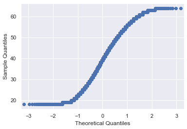

```python
#6.2.2 Type of distribution of "age"
sm.qqplot(ins_data["age"]);
print("\nAge Data: Quiet UNIFORM DISTRIBUTION")
```

```
1639.56310     2
8825.08600     1
43254.41795    1
5257.50795     1
1980.07000     1
Name: charges, dtype: int64
```

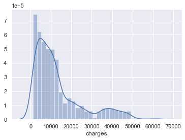

```python
#6.3 EDA-Distribution of "charges"
sns.distplot(ins_data["charges"]);
print(ins_data["charges"].value_counts().head())
```

```
MIN: 1121.8739
MAX: 63770.42801
MEAN: 13270.422265141257
MEDIAN: 9382.033
MODE: 1639.5631
Q1: 4740.28715
Q3: 16639.912515
```

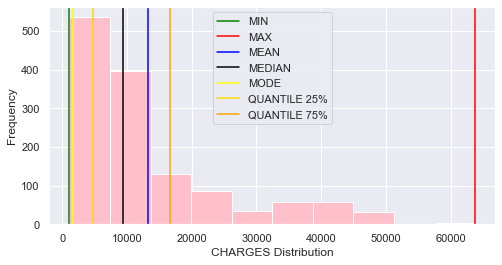

```python
#6.3.1 Main values of distribution of "charges"
minim = ins_data["charges"].min()
maxim = ins_data["charges"].max()
mean_val = ins_data["charges"].mean()
median_val = ins_data["charges"].median()
mode_val= ins_data["charges"].mode()
Q1_val = ins_data["charges"].quantile(0.25)
Q3_val = ins_data["charges"].quantile(0.75)
print(f"MIN: {minim}\nMAX: {maxim}\nMEAN: {mean_val}\nMEDIAN: {median_val}\nMODE: {mode_val[0]}\nQ1: {Q1_val}\nQ3: {Q3_val}")

plt.figure(figsize=(8,4))
plt.hist(ins_data["charges"],color="pink")

plt.axvline(minim,color="green",label="MIN")
plt.axvline(maxim,color="red",label="MAX")
plt.axvline(mean_val,color="blue",label="MEAN")
plt.axvline(median_val,color="black",label="MEDIAN")
plt.axvline(mode_val[0],color="yellow",label="MODE")
plt.axvline(Q1_val,color="gold",label="QUANTILE 25%")
plt.axvline(Q3_val,color="orange",label="QUANTILE 75%")

plt.xlabel("CHARGES Distribution")
plt.ylabel("Frequency")
plt.legend()
plt.show()
```

```
Charges Data: RIGHT SKEWED DISTRIBUTION
```

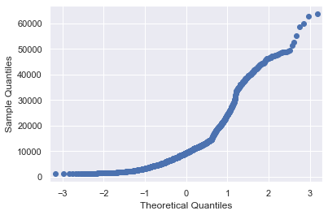

```python
#6.3.2 Type of distribution of "charges"
sm.qqplot(ins_data["charges"]);
print("\nCharges Data: RIGHT SKEWED DISTRIBUTION")
```

#### *EDA-Measure of skewness of "bmi","age", & "charges" columns*

```python
#7. EDA-Measure of skewness of "bmi","age" & "charges" columns
print(ins_data[["bmi","age","charges"]].skew())
print("\nBMI data: Zero Skewness\nAge data: Zero Skewness\nCharges data: Right skewness")
```

```
bmi        0.284047
age        0.055673
charges    1.515880
dtype: float64

BMI data: Zero Skewness
Age data: Zero Skewness
Charges data: Right skewness
```

### Skewness visualization using KDE plot.

```
Zero skewness
```

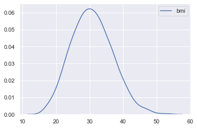

```python
sns.kdeplot(ins_data["bmi"]);
print("Zero skewness")
```

```
Zero skewness
```

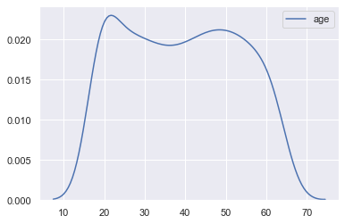

```python
sns.kdeplot(ins_data["age"]);
print("Zero skewness")
```

```
Right skew value : 1.5158796580240388
```

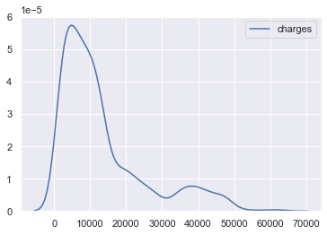

```python
sns.kdeplot(ins_data["charges"]);
char_skew = ins_data["charges"].skew()
print(f"Right skew value : {char_skew}")
```

#### *EDA-Checking the presence of outliers in "bmi","age", & "charges" columns*

```python
#Checking outliers using IQR.
outlier_data = ins_data[["bmi","age","charges"]]
Q1_check = outlier_data.quantile(0.25)
Q3_check = outlier_data.quantile(0.75)
result_IQR = Q3_check - Q1_check
print(result_IQR)
print((outlier_data < (Q1_check - 1.5 * result_IQR)) | (outlier_data > (Q3_check + 1.5  * result_IQR)))
```

```
bmi            8.397500
age           24.000000
charges    11899.625365
dtype: float64
        bmi    age  charges
0     False  False    False
1     False  False    False
2     False  False    False
3     False  False    False
4     False  False    False
...     ...    ...      ...
1333  False  False    False
1334  False  False    False
1335  False  False    False
1336  False  False    False
1337  False  False    False

[1338 rows x 3 columns]
```

```
9 Outliers are present
```

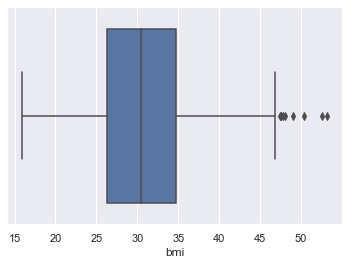

```python
#8.1 EDA-Checking the presence of outliers in "bmi" column.
sns.boxplot(ins_data["bmi"]);
outlier_count = (outlier_data < (Q1_check - 1.5 * result_IQR)) | (outlier_data > (Q3_check + 1.5  * result_IQR))
bmi_1_out_count = outlier_count["bmi"].sum()
print(f"{bmi_1_out_count} Outliers are present")
```

```
0 Outliers
```

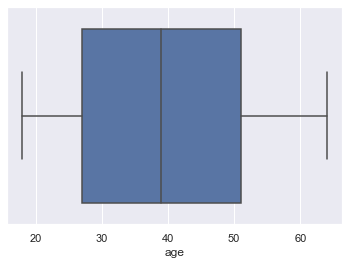

```python
#8.2 EDA-Checking the presence of outliers in "age" column.
sns.boxplot(ins_data["age"]);
age_1_out_count = outlier_count["age"].sum()
print(f"{age_1_out_count} Outliers")
```

```
139 Outliers are present
```

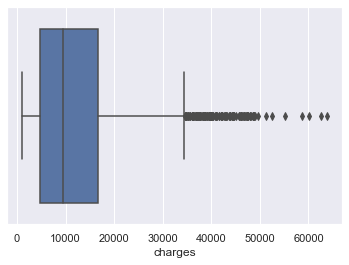

```python
#8.3 EDA-Checking the presence of outliers in "charges" column.
sns.boxplot(ins_data["charges"]);
charges_1_out_count = outlier_count["charges"].sum()
print(f"{charges_1_out_count} Outliers are present")
```

#### *EDA-Distribution of "sex","smoker", children & "region" categorical columns*

```
Male distribution: 676
Female distribution: 662
```

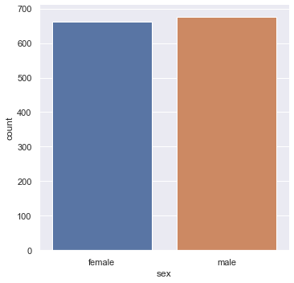

```python
#9.1 EDA-Distribution of categorical "sex" columns.
sns.catplot(x="sex",kind="count",data=ins_data);
male_1 = ins_data["sex"]=="male"
female_1 = ins_data["sex"]=="female"
print(f"Male distribution: {male_1.sum()}\nFemale distribution: {female_1.sum()}")
```

```
Smokers distribution: 274
Non Smokers distribution: 1064
```

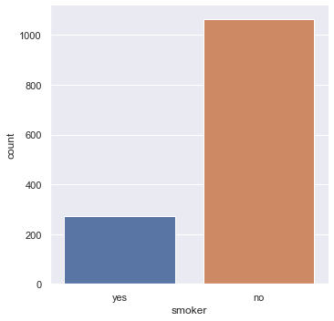

```python
#9.2 EDA-Distribution of categorical "smoker" columns.
sns.catplot(x="smoker",kind="count",data=ins_data);
smoker_1 = ins_data["smoker"]=="yes"
smoker_2 = ins_data["smoker"]=="no"
print(f"Smokers distribution: {smoker_1.sum()}\nNon Smokers distribution: {smoker_2.sum()}")
```

```
Region distribution:
South West: 325
South East: 364
North West: 325
North East: 324
```

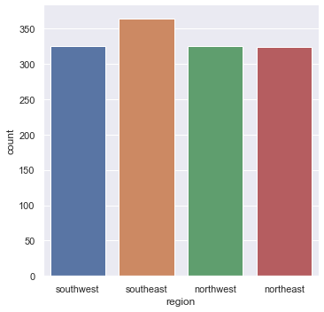

```python
#9.3 EDA-Distribution of categorical "region" columns.
sns.catplot(x="region",kind="count",data=ins_data);
region_1 = ins_data["region"]=="southwest"
region_2 = ins_data["region"]=="southeast"
region_3 = ins_data["region"]=="northwest"
region_4 = ins_data["region"]=="northeast"
print(f"Region distribution:\nSouth West: {region_1.sum()}\nSouth East: {region_2.sum()}\nNorth West: {region_3.sum()}\nNorth East: {region_4.sum()}")
```

```
0 Children: 574
1 Children: 324
2 Children: 240
3 Children: 157
4 Children: 25
5 Children: 18
```

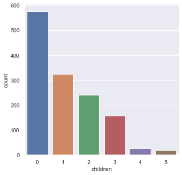

```python
#9.4 EDA-Distribution of categorical "children" columns.
sns.catplot(x="children",kind="count",data=ins_data);
children_0 = ins_data["children"]==0
children_1 = ins_data["children"]==1
children_2 = ins_data["children"]==2
children_3 = ins_data["children"]==3
children_4 = ins_data["children"]==4
children_5 = ins_data["children"]==5
print(f"0 Children: {children_0.sum()}\n1 Children: {children_1.sum()}\n2 Children: {children_2.sum()}\n3 Children: {children_3.sum()}\n4 Children: {children_4.sum()}\n5 Children: {children_5.sum()}")
```

Sex distributed evenly.  
High number of non smokers.  
Region distributed evenly.  
High values for 0 children.

#### *EDA-Pair plot that includes all the columns of the data frame*

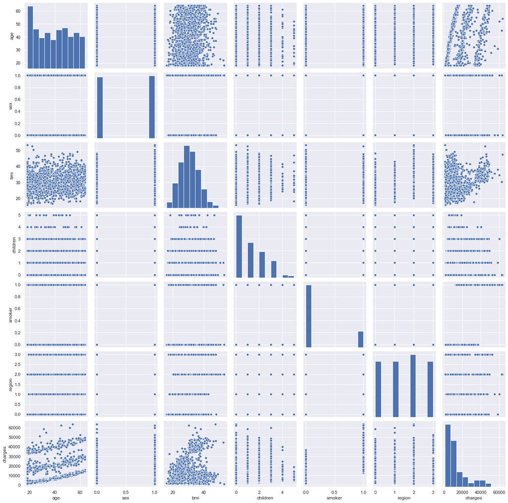

```python
#10 EDA-Pair plot that includes all the columns of the data frame.
ins_data_encode = ins_data.copy()
ins_data_encode.loc[:,["sex","smoker","region"]] = ins_data_encode.loc[:,["sex","smoker","region"]].apply(LabelEncoder().fit_transform)
sns.pairplot(ins_data_encode);
```

Positive relationship between Age & Charges.  
Obvious correlation of charges with smoker, smokers charges are higher than non-smokers.

#### *Do charges of people who smoke differ significantly from the people who don't ?*

### **As per below data visualization smokers carry high charges than non-smokers**

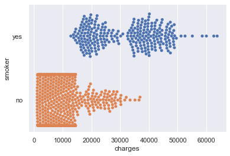

```python
sns.swarmplot(data=ins_data,x="charges",y="smoker");
```

```python
ins_data.smoker.value_counts()
```

```
no     1064
yes     274
Name: smoker, dtype: int64
```

```python
#T-test to check the dependency of smoking on charges.
Ho = "Charges are same" # Null Hypothesis
Ha = "Charges are not same" # Alternate Hypothesis

a = np.array(ins_data[ins_data.smoker == "yes"].charges) # Smokers charges
b = np.array(ins_data[ins_data.smoker == "no"].charges) # Non-smokers charges

t, p_value = stats.ttest_ind(a,b, axis = 0) # Independent t-test

if p_value < 0.05:
    print(f"{Ha} as the p_value {p_value} < 0.05")
else:
    print(f"{Ho} as the p_value {p_value} > 0.05")
```

```
Charges are not same as the p_value 8.271435842177219e-283 < 0.05
```

Smokers carry high charges than non-smokers

#### *Does BMI of males differ significantly from that of females ?*

```python
ins_data.sex.value_counts()
```

```
male      676
female    662
Name: sex, dtype: int64
```

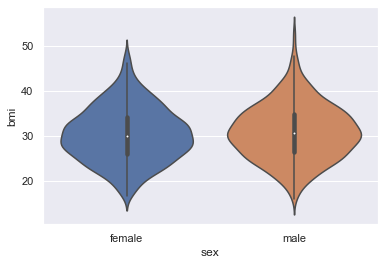

```python
sns.violinplot(data=ins_data,x="sex",y="bmi");
```

```python
# T-test to check dependency of bmi on sex
Ho = "sex has no effect on bmi"   # Null Hypothesis
Ha = "sex has an effect on bmi"   # Alternate Hypothesis

a = np.array(ins_data[ins_data.sex == 'male'].bmi)  # bmi values corresponding to males
b = np.array(ins_data[ins_data.sex == 'female'].bmi) # bmi values corresponding to females

t, p_value  = stats.ttest_ind(a,b, axis = 0)  # t-test

if p_value < 0.05:
    print(f'{Ha} as the p_value {p_value.round()} < 0.05')
else:
    print(f'{Ho} as the p_value {p_value.round(1)} > 0.05')
```

```
sex has no effect on bmi as the p_value 0.1 > 0.05
```

Similar BMI for both male & female

#### *Is the proportion of smokers significantly different in different genders ?*

```python
data_smokers = ins_data[ins_data["smoker"]=="yes"]
```

```python
data_smokers = data_smokers.groupby(["sex","smoker"]).size()
```

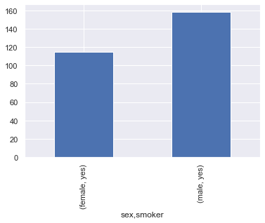

```python
data_smokers.plot(kind="bar");
```

```python
# Chi_square test to check the smoking trend among sex
Ho = "Gender has no effect on smoking"   # Null Hypothesis
Ha = "Gender has an effect on smoking"   # Alternate Hypothesis

crosstab_1 = pd.crosstab(ins_data['sex'],ins_data['smoker'])  # Cross table of sex and smoker attributes

chi, p_value, dof, expected =  stats.chi2_contingency(crosstab_1)

if p_value < 0.05:
    print(f'{Ha} as the p_value {p_value.round(3)} < 0.05')
else:
    print(f'{Ho} as the p_value {p_value.round(3)} > 0.05')
crosstab_1
```

```
Gender has an effect on smoking as the p_value 0.007 < 0.05
```

| smoker sex | no | yes |
| --- | --- | --- |
| female | 547 | 115 |
| male | 517 | 159 |

Yes the proportion of smokers significantly different in genders.

#### *Is the distribution of bmi across women with no children, one child and two children, the same ?*

```python
data_female = ins_data[(ins_data["sex"]=="female") & (ins_data["children"]<3)]
```

```python
data_female.head()
```

|  | age | sex | bmi | children | smoker | region | charges |
| --- | --- | --- | --- | --- | --- | --- | --- |
| 0 | 19 | female | 27.90 | 0 | yes | southwest | 16884.92400 |
| 5 | 31 | female | 25.74 | 0 | no | southeast | 3756.62160 |
| 6 | 46 | female | 33.44 | 1 | no | southeast | 8240.58960 |
| 9 | 60 | female | 25.84 | 0 | no | northwest | 28923.13692 |
| 11 | 62 | female | 26.29 | 0 | yes | southeast | 27808.72510 |

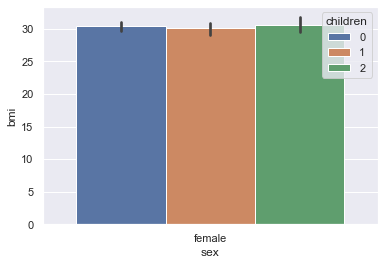

```python
sns.barplot(data=data_female,x="sex",y="bmi",hue="children");
```

```python
Ho = "No. of children has no effect on bmi"   # Null Hypothesis
Ha = "No. of children has an effect on bmi"   # Alternate Hypothesis

zero = data_female[data_female.children == 0]['bmi']
one = data_female[data_female.children == 1]['bmi']
two = data_female[data_female.children == 2]['bmi']


f_stat, p_value = stats.f_oneway(zero,one,two)


if p_value < 0.05:
    print(f'{Ha} as the p_value {p_value.round(3)} < 0.05')
else:
    print(f'{Ho} as the p_value {p_value.round(3)} > 0.05')
```

```
No. of children has no effect on bmi as the p_value 0.716 > 0.05
```

BMI is not changed by the number of children.